# Visualising vowel spaces with Praat and R

Jason Grafmiller

11 December, 2020

In this short tutorial I will show you how to plot the results of an analysis of vowels using R. If you haven’t watched the tutorials on how to use Praat for analyzing vowel formants, I recommend you do so before starting. Regardless, you can find the sound files, TextGrid files, Praat script, and resulting dataset on the class shared Google Drive.

To follow this tutorial this you will need the following packages:

```r
library(tidyverse) # for data handling
library(ggrepel) # for plotting
```

# 1 The data

Once we have the sound files and the TextGrids, we can run our script and extract the formant values. The script outputs a `.txt` file that we will use to plot our vowel spaces. You can open this file in Excel or any other text editor and look at it yourself.

We can just load this in like so. After we load it, we’ll do a bit of cleaning.

```r
formant_df <- read.delim("data/2020_sociolinguistics_wordlist_formants.txt")

formant_df <- formant_df %>%
  mutate(
    Speaker = str_replace_all(Filename, "_.*", ""), # add a column for speaker names
    Segment_label = str_trim(Segment_label) # remove trailing white space
  )

formant_df
```

| Filename | Segment_label | F1_start | F1_mean | F1_end | F2_start | F2_mean | F2_end | F3_start | F3_mean | F3_end | Speaker |
| --- | --- | --- | --- | --- | --- | --- | --- | --- | --- | --- | --- |
| Dana_Roemling_wordlist2 | heed | 295.6553 | 277.2827 | 296.3172 | 2686.6441 | 1825.5589 | 701.3637 | 3237.293 | 2941.410 | 2659.293 | Dana |
| Dana_Roemling_wordlist2 | hid | 386.8314 | 362.6933 | 324.6542 | 2101.4165 | 1589.8998 | 1981.4742 | 2771.278 | 2322.239 | 2771.814 | Dana |
| Dana_Roemling_wordlist2 | hayed | 564.9121 | 364.5429 | 312.7428 | 2213.5625 | 1312.8531 | 1582.3954 | 2902.826 | 2616.600 | 2659.640 | Dana |
| Dana_Roemling_wordlist2 | hide | 906.8703 | 707.5330 | 386.5014 | 1291.7930 | 1408.7783 | 1357.9102 | 2976.074 | 2615.309 | 2341.746 | Dana |
| Dana_Roemling_wordlist2 | head | 728.4622 | 608.8227 | 488.0721 | 1911.8337 | 1585.4374 | 1388.7581 | 2692.499 | 2496.481 | 1953.168 | Dana |
| Dana_Roemling_wordlist2 | had | 932.3054 | 834.3373 | 749.4865 | 1812.6800 | 1698.6419 | 1798.9866 | 2919.839 | 2823.947 | 2786.495 | Dana |
| Dana_Roemling_wordlist2 | who'd | 291.5577 | 331.5356 | 315.3543 | 1123.4805 | 1080.8279 | 1432.3171 | 2728.282 | 2707.241 | 2491.223 | Dana |
| Dana_Roemling_wordlist2 | hood | 312.0546 | 376.9664 | 406.3298 | 1470.2542 | 1547.5534 | 1672.3356 | 2486.666 | 2423.816 | 2718.567 | Dana |
| Dana_Roemling_wordlist2 | hoed | 690.6287 | 463.8062 | 374.8796 | 1314.4080 | 1223.3514 | 1335.9600 | 2654.804 | 2680.248 | 2647.665 | Dana |
| Dana_Roemling_wordlist2 | hawed | 798.8887 | 736.9124 | 718.8729 | 961.8436 | 1063.2935 | 1187.0343 | 2824.188 | 2784.318 | 2730.725 | Dana |

[output cut: 146 more lines]

# 2 Plotting the vowel space

Now that we have the data, it’s very easy to plot the F1 and F2 values for each vowel. We’ll start with the monophthongs: /i, ɪ, ε, æ, u, ʊ, ɔ, ʌ/.

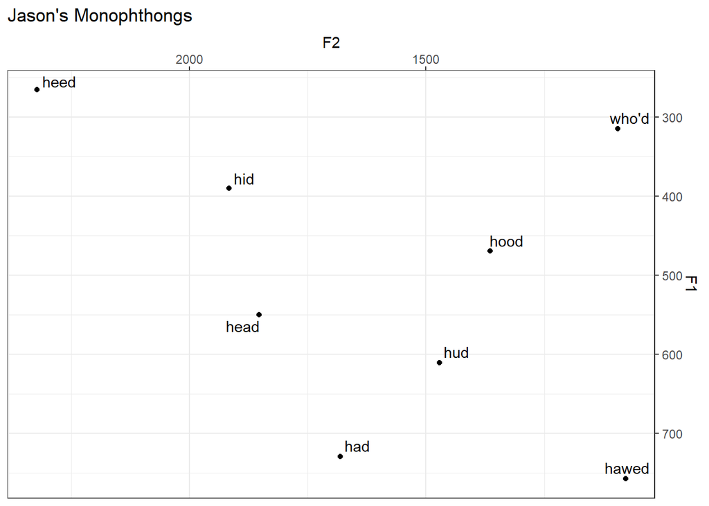

```r
formant_df %>%
  # We'll filter out the diphthongs
  filter(!Segment_label %in% c("hide", "hayed", "how'd", "hoed"),
         Speaker == "Jason") %>%
  ggplot(aes(F2_mean, F1_mean)) +
  geom_point() +
  geom_text_repel(aes(label = Segment_label)) +
  scale_y_reverse(position = "right") +
  scale_x_reverse(position = "top") +
  labs(title = "Jason's Monophthongs", y = "F1", x = "F2")
```

This looks like a typical distribution of American English vowels. These are perhaps a bit more dispersed (spread out) due to the nature of the wordlist task, as I was carefully articulating each sound to make them as distinct as possible. In more casual speech we’d probably find slightly different values for some vowels, e.g. the vowel in *hawed*.

A few things we might note:

- My /u/ vowel in *who’d* is a bit further to the left (a higher F2) than we might find for other American English varieties. This is possibly a reflection of an ongoing change in some varieties of American English, where the /u/ and /o/ vowels are “fronting”, i.e. their articulation is moving farther forward in the mouth. (We’ll see how this compares to British English below)
- My vowel in *had* is perhaps a bit farther forward (again, higher F2) than we might see in others’ vowel spaces. This is again an aspect of my American accent. In many British accents this vowel is farther back.
- My pronunciation of the vowel in *hawed* here is probably not representative of my actual speech. Again, I was ‘hyperarticulating’ these sounds in the task here. Typically *hawed* would rhyme with *hod* for me (or think of *hottie* vs. *haughty*, which are identical for many Americans). General American English has largely lost the contrast between the vowels in words such as *cot* and *caught*, which are pronounced identically in General American English. Linguists thus refer to this change as the ‘cot-caught merger’. Vowel mergers are generally a very common type of language change, and other examples of mergers in English include the well-known merger of the vowels in *foot* and *strut* in Northern England, and the merger of vowels in *look* and *Luke* in some Scottish accents. If you want to really have fun, ask people how they pronounce the words *merry*, *marry*, and *Mary* (they’re all the same to me!)

Moving on to my diphthongs, we can clearly see the transitions in the vowels of words like *hide* and *how’d*. What we usually show with diphthongs is a plot with arrows, where the base is at the onset (start) of the vowel, and the head points to the offset (end) of the vowel. The arrow shows us the “movement” through the vowel space, so to speak.

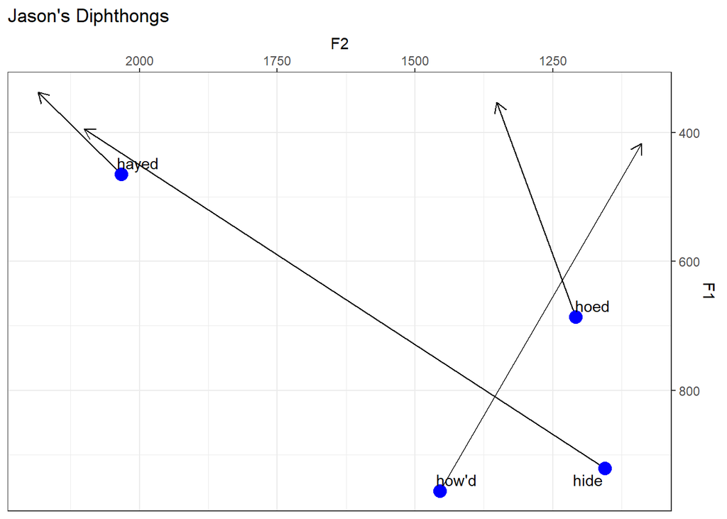

```r
formant_df %>%
  # We'll filter out the diphthongs
  filter(Segment_label %in% c("hide", "hayed", "how'd", "hoed"),
         Speaker == "Jason") %>%
  ggplot(aes(F2_start, F1_start)) +
  geom_segment(aes(yend = F1_end, xend = F2_end), arrow = arrow(length = unit(0.3, "cm"))) +
  geom_point(size = 4, color = "blue") +
  geom_text_repel(aes(label = Segment_label)) +
  scale_y_reverse(position = "right") +
  scale_x_reverse(position = "top") +
  labs(title = "Jason's Diphthongs", y = "F1", x = "F2")
```

For what it’s worth, if I were to transcribe my diphthongs, it would look something like this:

- *hayed*: /heid/
- *hide*: /haid/
- *hoed*: /hʌud/ or /hʌʊd/
- *how’d*: /hæʊd/

# 3 Everyone’s monophthongs

Below is the plot of everyone’s vowels (or at least those from whom I have data…)

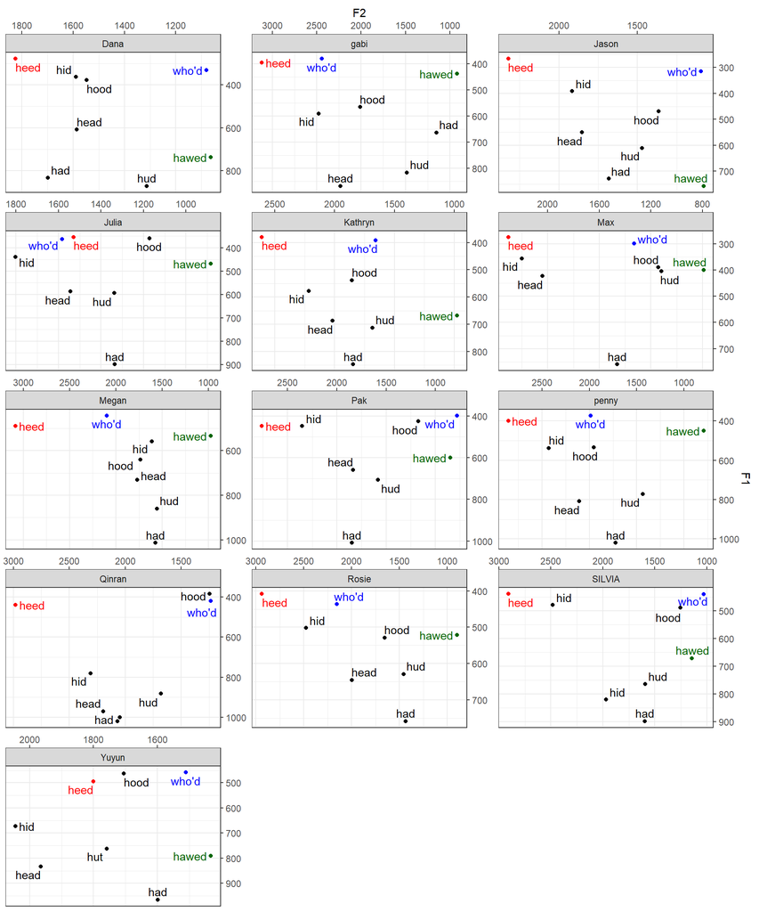

```r
p3 <- formant_df %>%
  # We'll filter out the diphthongs
  filter(!Segment_label %in% c("hide", "hayed", "how'd", "hoed")) %>%
  mutate(
    colors = case_when(
      Segment_label == "who'd" ~ 1,
      Segment_label == "heed" ~ 2,
      Segment_label == "hawed" ~ 3,
      TRUE ~ 0
    ) %>%
      as.factor()
  ) %>%
  ggplot(aes(F2_mean, F1_mean, color = colors)) +
  geom_point() +
  geom_text_repel(aes(label = Segment_label)) +
  scale_y_reverse(position = "right") +
  scale_x_reverse(position = "top") +
  scale_color_manual(guide = "none", values = c("black", "blue", "red", "darkgreen")) +
  facet_wrap(~ Speaker, scales = "free", ncol = 3) +
  labs(y = "F1", x = "F2")
p3
```

Again, this looks pretty good, and there are some fun patterns that are worth pointing out.

Take for example the case of the vowel *who’d* in blue. We have a curious kind of split within the class between those whose vowel is fairly far back—Dana, Pak, myself—and those whose vowel is relatively farther forward—Gabi, Kathryn, Megan, Penny, and Rosie (Julia is a puzzling case that I’ll return to below). What’s interesting is that the latter group are (almost) all speakers of British English, while those in the other group are not. I mentioned the fact that my own accent shows evidence of “fronting” of the vowel in *who’d*, but it turns out this change in American English has nothing on British English, where many varieties outside the North have undergone a rather substantial shift over the last 50 years or so towards a very fronted vowel (see e.g. Strycharczuk & Scobbie 2017).

If you listen closely, you should be able to hear the difference in my pronunciation of *who’d* compared to those of Megan and Penny (If you don’t hear the difference, don’t feel bad. It takes a lot of practice and training your ears to pick on subtle differences like these).

**Jason:**

```r
html_tag_audio("jason_whod.wav", type = "wav")
```

[interactive chart not shown]

**Megan:**

```r
html_tag_audio("megan_whod.wav", type = "wav")
```

[interactive chart not shown]

**Penny:**

```r
html_tag_audio("penny_whod.wav", type = "wav")
```

[interactive chart not shown]

So back to Julia’s *who’d*… What’s up with that? I highly doubt that her *who’d* vowel is farther forward than her *heed* vowel, but that is what the plot is telling us. We can test this by ear, and see that the plot must be wrong.

**Julia** *heed*:

```r
html_tag_audio("julia_heed.wav", type = "wav")
```

[interactive chart not shown]

**Julia** *who’d*:

```r
html_tag_audio("julia_whod.wav", type = "wav")
```

[interactive chart not shown]

So it seems our analysis is off. What likely happened is that Praat made an error calculating the F2 for this vowel. If we look at the spectrogram it seems that Praat is detecting a phantom formant and using this in its calculation of her mean F2 (notice the odd red dots in the middle where there are no corresponding dark bars).

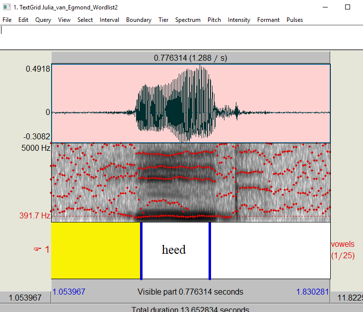

Julia’s *heed* Spectrogram

My guess is that this is what is causing our unusual plots. This is something that often happens with imperfect software. Ideally we would have many recordings of our vowels, which would help smooth over some of these occasional measurement errors. But oh well…

# 4 Everyone’s diphthongs

These are even more fun. I don’t have time to go through these in detail, but it should be clear that there is a lot of variation in our class! With diphthongs we usually focus on the starting and end points to see where differences lie. For instance, it seems that while Kathryn’s vowel in *hoed* begins farther forward than my own, they both largely end in the same place. If I were to transcribe them, it might be something like /həud/ and /hʌud/ respectively.

Again there are also some unexpected patterns that are likely due to measurement error more than anything else (e.g. Dana’s and Julia’s *hayed* vowels are going in the wrong direction), but that is certainly not all there is.

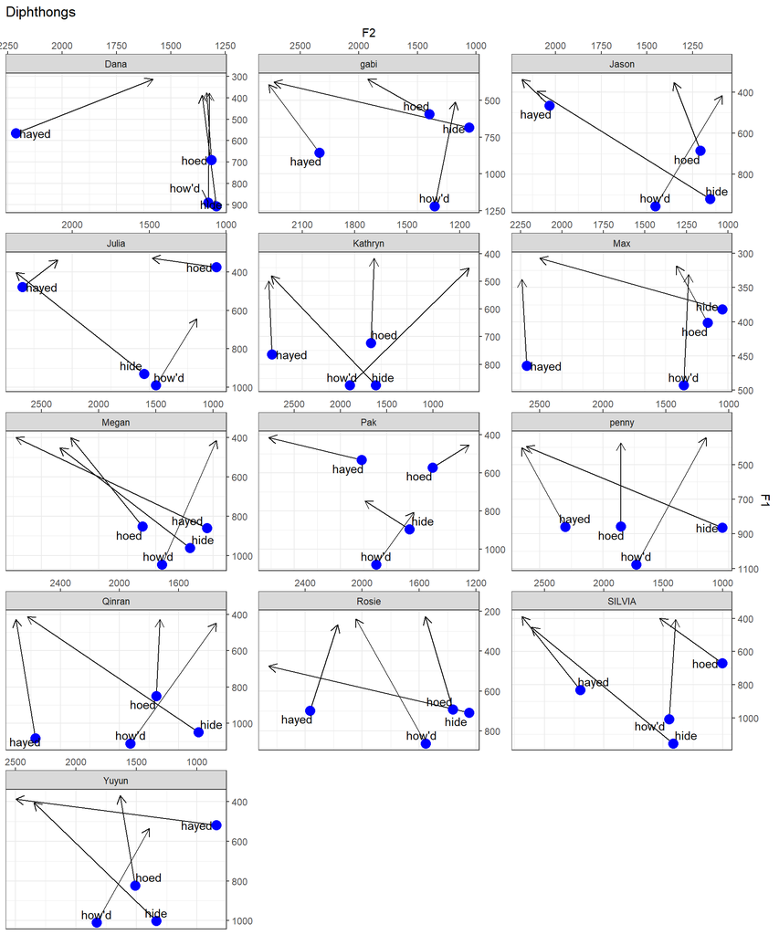

```r
formant_df %>%
  # We'll filter out the diphthongs
  filter(Segment_label %in% c("hide", "hayed", "how'd", "hoed")) %>%
  ggplot(aes(F2_start, F1_start)) +
  geom_segment(aes(yend = F1_end, xend = F2_end), arrow = arrow(length = unit(0.3, "cm"))) +
  geom_point(size = 4, color = "blue") +
  geom_text_repel(aes(label = Segment_label)) +
  scale_y_reverse(position = "right") +
  scale_x_reverse(position = "top") +
  facet_wrap(~ Speaker, scales = "free", ncol = 3) +
  labs(title = "Diphthongs", y = "F1", x = "F2")
```

Anyway, that’s all I have time for now. There are lots of other tutorials and help available online. For some very detailed introductions, I recommend these by Joey Stanley:

- https://joeystanley.com/pages/praat-workshops
- https://joeystanley.com/blog/making-vowel-plots-in-r-part-1

# Refereneces

Strycharczuk, Patrycja & James M. Scobbie. 2017. Fronting of Southern British English high-back vowels in articulation and acoustics. *The Journal of the Acoustical Society of America* 142(1). Acoustical Society of America. 322–331. doi:10.1121/1.4991010.